# Identification and Estimation of Demand Models with Endogenous Product Entry and Exit

Aguirregabiria, Iaria, and Sokullu (2024)

José Ignacio González Rojas

j.i.gonzalez-rojas@lse.ac.uk

London School of Economics and Political Science

October 29, 2024

## Motivation

- Firms’ decisions to enter and exit markets consider whether they can profitably serve consumers on expectation in that market.
  - Additional adjustment margin other than prices and quantities.
  - Sample selection bias in demand estimation.
- Applications in laundry machines (Thomas, 2011), and this paper on airline industry (Aguirregabiria et al., 2024). More recently, (Sabal, 2024) in the global automobile industry.
- This paper: Demand estimation of differentiated products accounting for the endogeneity of firms’ entry and exit decisions.

## Model

### Demand

- Households $h$, products $j$, and markets $j$.
- Discrete choice model with random coefficients a la S. Berry et al. (1995).

$$U_{hjt} \equiv \delta(p_{jt}, x_{jt}) + v(p_{jt}, x_{jt}, \upsilon_{ht}) + \epsilon_{hjt}$$

$$\delta_{jt} \equiv \alpha p_{jt} + x_{jt}' \beta + \xi_{jt}$$

- $\upsilon_{ht}$: random coefficients.
- $\epsilon_{hjt}$: EVD T1.

## Model

### Demand

#### Inversion of demand system

$$s_{jt} = d_{jt}(\delta_t, a_t) \equiv \int \frac{\textcolor{orange}{a_{jt}}\exp (\delta_{jt} + v(p_{jt}, x_{jt}, \upsilon))}{1 + \sum_{i=1}^J \textcolor{orange}{a_{it}} \exp (\delta_{it} + v(p_{it}, x_{it}, \upsilon))} dF_{\upsilon}(\upsilon)$$

- Consumers only buy products available in their market.
- The outside option is always available.
  - $s^{(a)}_t = d^{(a)}_t(\delta^{(a)}_t)$ is always invertible (S. T. Berry, 1994).

## Model

### Supply

Two-stage game.

#### **Second stage:** Active firms $j$ on market $t$ choose prices.

- Firm’s problem:
  $$\max_{p_{jt}} \left\{p_{jt} d^{(a)}_{jt}(p_{jt}, \cdot) H_{t} - c(d^{(a)}_{jt}(p_{jt}, \cdot) H_{t}; x_{jt}, \omega_{jt}) - f(x_{jt}, \eta_{jt}) \right\}$$
- Nash-Bertrand equilibrium:
  $$p_{jt}^{*} = \frac{\partial c(\cdot, \cdot)}{\partial q_{jt}} - d^{(a)}_{jt}(\cdot, \cdot) \left( \frac{\partial d^{(a)}_{jt}(\cdot, \cdot)}{\partial p_{jt}} \right)^{-1} \quad \forall j \in J$$

## Model

### Supply

#### **First stage:** Firms $j$ decide whether to enter each market $t$ individually.

- Given $(x_{t}, \kappa_{t}, \eta_{jt})$,
  - $\kappa_{t}$: public signal for the demand-cost variables $(\xi_{t}, \omega_{t})$.
  - $\eta_{jt}$: i.i.d. private signal for information of firm $j$.
- Firm enters the market if:
  $$\mathbb{E}[\pi_{j}(a_{-j}, x_{t}, \kappa_{t}, \eta_{jt})|x_{t}, \kappa_{t}]\geq 0.$$

## Model

### Supply

#### **First stage:** Firms $j$ decide whether to enter each market $t$ individually.

#### Solution concepts

- The entry probability depends on the combinatorial problem of whether each firms $-j$ also enters the market.
- Find entry probabilities $\mathbb{P}_{jt}(x_{t}, \kappa_{t}) = \mathbb{P}[a_{jt} = 1 |x_{t}, \kappa_{t}]$.
- **Static:** Bayesian Nash Equilibrium
  - Single product firms.
  - Multi product firms.
- **Dynamic:** Markov Perfect Equilibrium.

## (Sample) selection problem

- Selection propensity score $\bar{P}_{jt} \equiv \mathbb{P}[a_{jt}= 1|x_{t}].$
- Selection bias function $\lambda_{j}(x_{t}) \equiv \mathbb{E}[\xi_{jt}|x_{t}, a_{jt} = 1] = \frac{\mathbb{E}[\xi_{jt}\mathbb{1}[a_{jt} = 1]|x_{t}]}{\bar{P}_{jt}}.$
- (When) can we use selection propensity score to control for the selection bias (Angrist, 1997)?
  - $\mathbb{P}[\xi_{jt}, a_{jt}|x_{t}, \bar{P}_{jt}] = \mathbb{P}[\xi_{jt}, a_{jt}| \bar{P}_{jt}]$.
  - **Example:** single-crossing structure in the entry decision.
- **Additional assumption:** $P_{jt}(x_{t}, \kappa_{jt}) = \mathbb{P}[\xi_{jt}, a_{jt}|x_{t}, \kappa_{t}, \bar{P}_{jt}] = \mathbb{P}[\xi_{jt}, a_{jt}| \kappa_{t}, \bar{P}_{jt}].$
  - **Structural condition:** Strict monotonicity of the profit function with respect to $\eta_{jt}$.

## (Sample) selection problem

- **Unobservables matter:** integration over private signal $\eta_{jt}$ and public signal $\kappa_{t}$.
- $\psi_{j}(P_{j}(\textcolor{orange}{x_{t}}, \kappa_{t}), \textcolor{orange}{x_{t}}) \equiv \mathbb{E}[\xi_{jt}|x_{t}, \kappa_{t}, a_{jt} = 1]$ and $\theta(\textcolor{orange}{x_{t}}) \equiv (\alpha, \beta, \sigma).$
- **Solution:** There’s a discrete proxy/latent-variable $\kappa_{t}^{*}$ where the same property holds.

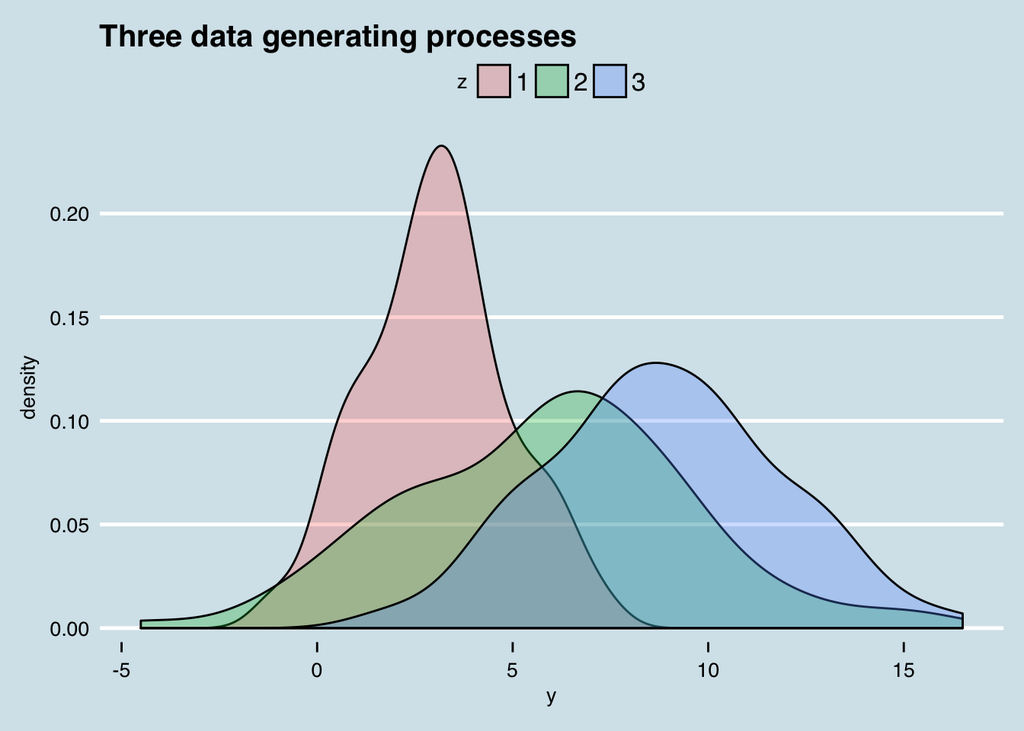

Finite mixture model

## Identification

$$\theta = \left( \textcolor{orange}{\theta_{\delta}}, P_{\kappa^{*}}, f_{\kappa^{*}}, f_{\xi | \eta, \kappa^{*}}, F_{\eta} \right)$$

- $\theta_{\delta}$: Demand parameters
- $P_{\kappa^{*}}$: Entry probabilities for each latent type.
- $f_{\kappa^{*}}$: Distribution of latent types.
- $f_{\xi | \eta, \kappa^{*}}$: Distribution of demand unobservables conditional on latent types and private information.
- $F_{\eta}$: Distribution of private information shocks.

## Identification

They propose by a two-step estimation procedure.

1. Given the empirical distribution of firms’ entry decisions, we establish the identification of the equilibrium probabilities $P_{\kappa^{*}}$, and the distribution $f_{\kappa^{*}}$.
2. Given the selection bias function $\lambda_{j}(x_{t})$, we show the identification of $\theta_{\delta}$.

## Identification

### First step: Game of market entry

1. Given the empirical distribution of firms’ entry decisions, we establish the identification of the equilibrium probabilities $P_{\kappa^{*}}$, and the distribution $f_{\kappa^{*}}$.
   $$\mathbb{P}(a_{t} = a | x_{t}) = \sum_{\kappa^{*} \in K(x_{t})} f_{\kappa^{*}}(\kappa^{*} | x_{t}) \prod_{j=1}^{J} \left[P_{j}(x_{t}, \kappa^{*}) \right]^{a_{jt}} \left[ 1 - P_{j}(x_{t}, \kappa^{*}) \right]^{1 - a_{jt}}$$
- The entry probability $P_{j}(x, κ^{*})$ of each firm $j$ conditionally independent from the others $P_{i}(x, κ^{*}), i \neq j$.
- The identification number of latent types relies on having a large sample.
- $\kappa_{t}$ and $x_{t}$ are independent. (Application specific)

## Identification

### Second step: Identification of Demand Parameters

- Controlling for selection bias on the mean utility regression, demand parameters are identified.
- After controlling for it, there should be remaining variation on $x_{t}$.
- The vector of entry probabilities $P_{jt}$ should depend on $x_{it}$ for $i \neq j.$

## Estimation

Given the constructive identification procedure, estimation is straightforward.

### First step: Game of market entry

- **Functional forms:**
  - $f_{\kappa^{*}}(\kappa^{*} | x_{t})$: sieves multinomial logit structure.
  - $P_{j}(x, κ^{*})$: sieves binary logit structure.
- **Estimation method:** Maximum Likelihood (MLE) using the Expectation–maximization algorithm.

### Second step: Identification of Demand Parameters

- **Functional forms:** Method of sieves and approximate each function $\psi_{j}(P_{j}(x_{t}, \kappa_{t}), x_{t})$ using a polynomial of order $L$ in the logarithm of the entry probability $P_{j}(x_{t}, \kappa_{t}).$
- **Estimation method:** Generalised Method of Moments.

## Empirical application: Airline industry

- Markups **drop** substantially:
  - Benchmark (2SLS no selection): 1.25.
  - Controlling for selection (Finite mixture model (3 latent types)): 1.17.
- Own-price elasticities are **higher**.
  - Benchmark (2SLS no selection): −5.549.
  - Controlling for selection (Finite mixture model (3 latent types)): −8.000.

## Further research directions

- Sabal (2024): Global automobile industry. Endogenous product entry and exit, heterogenous firms, and demand estimation. Bounds on the demand parameters. Timing of the game.
- Arkolakis et al. (2023): Trade and entry costs. Plant location. Economic intuition: explicit trade-off. Cannibalisation among production plants and substitution effects between them.

## References

Aguirregabiria, V., Iaria, A., & Sokullu, S. (2024). *Identification and Estimation of Demand Models with Endogenous Product Entry and Exit* [Working Paper].

Angrist, J. D. (1997). Conditional independence in sample selection models. *Economics Letters*, *54*(2), 103–112. https://doi.org/10.1016/S0165-1765(97)00022-0

Arkolakis, C., Eckert, F., & Shi, R. (2023). *Combinatorial Discrete Choice: A Quantitative Model of Multinational Location Decision* (Working Paper No. 31877). National Bureau of Economic Research. https://doi.org/10.3386/w31877

Berry, S. T. (1994). Estimating Discrete-Choice Models of Product Differentiation. *RAND Journal of Economics*, *25*(2), 242–262. https://doi.org/10.2307/2555829

Berry, S., Levinsohn, J., & Pakes, A. (1995). Automobile Prices in Market Equilibrium. *Econometrica*, *63*(4), 841–890. https://doi.org/10.2307/2171802

Sabal, A. (2024). *Product Entry in the Global Automobile Industry* [Working Paper].

Thomas, C. (2011). Too Many Products: Decentralized Decision Making in Multinational Firms. *American Economic Journal: Microeconomics*, *3*(1), 280–306. https://doi.org/10.1257/mic.3.1.280